# Final Paper

STOR 320.01 Group 15

December 05, 2019

# INTRODUCTION

Data analytics is now imperative in the sports industry. According to **[Molly Olsofka of Samford University](https://www.samford.edu/sports-analytics/fans/2018/Why-is-Data-Analytics-So-Important-in-Sports)**, analysts in this field work with various metrics that help teams increase revenue, improve player performance, prevent injuries, and more. The National Basketball Association (NBA), one of the most popular and fast-growing professional sports leagues in North America, has several data science departments for specific teams as well as within their own headquarters. Therefore, due to the growing prevalence of sports analytics and our passion for basketball, our group decided to evaluate an NBA Player Statistics dataset. Through exploratory analysis, we created various questions and generated different models to answer each. We found two questions particularly fascinating and worthy of further investigation: “At what age is the average NBA player in the prime of their career?” and “Which factors most influence rebounding for NBA players?”

The first question stems from the results of our initial investigation, in which we found that the ages at which players score the most points, grab the most rebounds, and get the most assists was surprisingly similar. We therefore decided to explore the “peak” of an NBA player’s career, and we believe these results appeal to several sports pundits, fans, and team managers. Specifically, this information can be helpful to determine the superiority of some players over others. For example, LeBron James is currently 34 years old, whereas Kevin Durant is 31 years old. Our results would imply that Durant is much closer to the “peak” of his career than James. However, does this suggest that Durant is a better player than James? Questions such as this and a general overview of the prime of various players’ careers would most definitely be appealing to ESPN commentators such as Stephen A. Smith, who often debate such topics. In addition, this information can be useful for team managers and coaches in instances such as deciding whether or not to trade a player who is at the tailend of their prime years for a player who is entering their prime years. In summation, knowing when the average NBA player will peak in on-court output can definitely be useful information for a wide variety of NBA-adjacent individuals.

The second question also derives from our initial investigation, in which we discovered that a good amount of the NBA’s best rebounders are also those in the upper percentiles of height. This makes sense for several reasons, for instance the rim of the basket is at 10 feet tall meaning the taller you are the easier it is to rebound. However there are still many shorter players who have records of rebounding extremely well. UNC Freshman Cole Anthony for example stands at 6’3” and is notably shorter in comparison to his teammates, yet this does not stop him from attacking the glass. The level that Anthony and NBA players of similar height, like Russell Westbrook and Dwayne Wade, demonstrate while rebounding negated our original results, and therefore prompted us to look at what else can explain rebounding success for players. This information will be interesting not only to fans of the NBA, but also sports commentators and pundits who often just correlate taller height with stronger rebounder. Hence, we strongly believe that the results to our data will be useful and informative to many NBA-adjacent individuals since our results could help them better understand what goes into rebounding success.

# DATA

The dataset we utilized throughout this project was sourced from Kaggle, an online resource which facilitates the locating of datasets for data scientists. The dataset we found in particular is called “NBA Player stats since 1950”, a dataset which stays very true to its name in its content. The dataset was web-scraped from a website called Basketball Reference, a subsidiary of Sports Reference which also maintains other sports-related sites, which contains historical data for the NBA since 1950. The dataset was compiled into 3 Comma Separated Values files (csv), one which contained statistics for each player by season, one which contained information about each player such as date of birth and college, and one which contained physical information about each player, such as height and weight. This dataset was the basis of our entire project.

In order to answer the first question, we utilized a variety of advanced metrics and grouping variables to predict when a particular player will hit their prime. The main metrics our analysis relied upon were Value Over Replacement Player (VORP), Player Efficiency Rating (PER), Box Plus - Minus (BPM), and Win Shares (WS). VORP measures the contributions of a player relative to the contributions of an average player at that position. PER is an all encompassing basketball metric, calculated by factoring in virtually every discrete basketball metric possible, like shot attempts, points, rebounds, assists, etc. The formula can be seen from **[Basketball Reference](https://www.basketball-reference.com/about/per.html)**. BPM is a measure of a team’s performance with a player on or off the court over the course of 100 possessions with a replacement baseline of -2. A player with a BPM of 3 means that their team is 3 points better than average with that player on the court per 100 possessions they play. Finally, WS is a measure of a player’s overall contribution to each win a team earns. Win Shares per 48 minutes are potentially more significant in determining player performance, but because we are looking at a player’s prime, longevity over a season (more total WS) is more important. All of these metrics were calculated for each player over the course of every season they played, making each observation representative of a player’s performance over a whole NBA season. Metrics were calculated the same for every NBA player, not just players who met a certain criteria. The methodology behind it will be explained in greater detail, but each of these 4 advanced metrics went into a weighted average named weightedIndex, a metric we created to determine when players we had information for had hit their prime.

The other information which was necessary for this analysis was information about players themselves. We utilized categorical information about player’s birth states or countries, colleges they attended, and the positions they played in order to predict their prime year. We also used numerical information about the players, such as height (in inches), weight (in pounds), and the age they were when they played their first NBA season. Finally, we used simple counts of points, rebounds, and assists in order to determine when a player had hit their prime, as well as points, rebounds, and assists totals from a player’s first season in the NBA to predict when an unknown player would hit their prime. For all of these metrics, their values were stagnant, things which did not change from season to season, and things that every NBA player had in common. After cleaning our data, we had a total of 3,134 observations.

|  | Player | prime | weightedIndex | ageEnteredNBA | College | birth_state | height | weight | Pos | Y1PTS | Y1AST | Y1REB |
| --- | --- | --- | --- | --- | --- | --- | --- | --- | --- | --- | --- | --- |
| 1 | Michael Jordan* | 25.00 | 28.49 | 21.00 | University of North Carolina | New York | 77.95 | 194.01 | Guard | 2313.00 | 481.00 | 534.00 |
| 2 | Russell Westbrook | 28.00 | 28.18 | 20.00 | University of California, Los Angeles | California | 74.80 | 198.42 | Guard | 1256.00 | 435.00 | 399.00 |
| 3 | LeBron James | 24.00 | 27.73 | 19.00 | No College | Ohio | 79.92 | 249.12 | Forward | 1654.00 | 465.00 | 432.00 |
| 4 | David Robinson* | 28.00 | 26.13 | 24.00 | United States Naval Academy | Florida | 85.04 | 233.69 | Center | 1993.00 | 164.00 | 983.00 |
| 5 | Kareem Abdul-Jabbar* | 28.00 | 25.88 | 26.00 | University of California, Los Angeles | New York | 85.83 | 224.87 | Center | 2191.00 | 386.00 | 1178.00 |
| 6 | Chris Paul | 23.00 | 25.39 | 20.00 | Wake Forest University | North Carolina | 72.05 | 174.16 | Guard | 1258.00 | 611.00 | 400.00 |
| 7 | Kevin Garnett | 27.00 | 24.94 | 19.00 | No College | South Carolina | 83.07 | 238.10 | Forward | 835.00 | 145.00 | 501.00 |
| 8 | Stephen Curry | 27.00 | 24.57 | 21.00 | Davidson College | Ohio | 74.80 | 189.60 | Guard | 1399.00 | 472.00 | 356.00 |
| 9 | Shaquille O’Neal* | 27.00 | 24.34 | 20.00 | Louisiana State University | New Jersey | 85.04 | 324.08 | Center | 1893.00 | 152.00 | 1122.00 |
| 10 | James Harden | 27.00 | 24.14 | 20.00 | Arizona State University | California | 77.17 | 218.26 | Guard | 753.00 | 137.00 | 244.00 |

To examine rebounding percentages, we must examine the per season statistics we collected from Basketball Reference. This data set provides seasonal statistics for every player in the NBA dating back to the inception of the NBA in 1950. However, we cannot start our analysis with the data from 1950. The NBA has undergone a multitude of changes in terms of both rules and popularity since its inception, and thus so have the ways in which statistics for NBA players are recorded. Counting statistics (points, rebounds, assists, etc.) as we know them today were not all recorded until 1978, the 3-point line was not implemented until 1980, and advanced metrics that measure efficiency have been calculated retrospectively for these seasons. For this reason, we begin our assessment in 1980, where we have full data for every player. Offensive and defensive rebounding percentages (we will refer to offensive rebounding percentage as ORB. and defensive rebounding percentage as DRB.) are calculated by determining the percent of available offensive or defensive rebounds that a player accounts for while on the court. The formula for offensive rebounding percentage is: $ORB. = 100 * (ORB * (Tm MP / 5)) / (MP * (Tm ORB + Opp DRB))$ where ORB. is offensive rebounding percentage, ORB is a player’s offensive rebounds, Tm MP is the team’s minutes played, which equates to 19680 (5 players on the court for 4-12 minute quarters for 82 games = 19680 available minutes), MP is the minutes the player plays over that season, Tm ORB is the total number of offensive rebounds that the player’s team records while on the court and Opp DRB is the total number of offensive rebounds that the opposing team records while that player is on the court. Defensive rebounding percentage can be calculated by swapping ORB and DRB in this formula. Many fringe players that only play in a few games each season may have drastically skewed, both on the low and high ends, as a player may grab the only available offensive rebound during the final minutes of the game and thus have a 100% offensive rebounding percentage, so we must restrict our player pool. Most NBA teams have an average rotation of 10 players, or more simply, we expect each team to play on average 10 players during a given game. Because we want to examine only players that are consistent in NBA rotations, we restrict our player pool to only include those players that played at least 1968 minutes per season.

When determining which variables to include in our model, we must first account for those that are included in the calculation of offensive and defensive rebounding percentage. If we include these variables, the formula for $ORB%$ and $DRB%$ can be reverse engineered to create a model using only the variables in the formula. Thus, we must remove minutes played ($MP$), total offensive rebounds ($ORB$) and total defensive rebounds ($DRB$). Next we must look for multicollinearity amongst variables. Collinear variables are predictors that are actually just linear combinations of other predictors. For example, field goal percentage is a linear combination of field goals made and field goals attempted, so if we include this variable, we are essentially double counting a player’s field goals and field goal percentage twice. After variable selection, we are left with: Age, True Shooting Percentage $TS%$, 3 Point Attempt Rate $3PAr$, Free Throw Rate $FTr$, Assist Percentage $AST%$, Steal Percentage $STL%$, Block Percentage $BLK%$, Turnover Percentage $TO%$, Offensive Win Shares $OWS$, and Defensive Win Shares $DWS$. TS. measures shooting efficiency and considers field goals, three point field goals, and free throws. 3PAr is the amount of three point field goals attempted relative to the total field goals attempted by a player. FTr is the ratio of foul shots to field goals attempted by a player. AST. is how many assists a player gets out of the total assists to be gotten. STL., BLK., TO., ORB, and DRB are calculated in the same way just with steals, blocks, turnovers, offensive rebounds, and defensive rebounds respectively. OWS are win shares due to offensive production (points produced and offensive possessions) and DWS are win shares due to a player’s defensive rating which is calculated by estimating the number of points allowed per 100 defensive possessions.

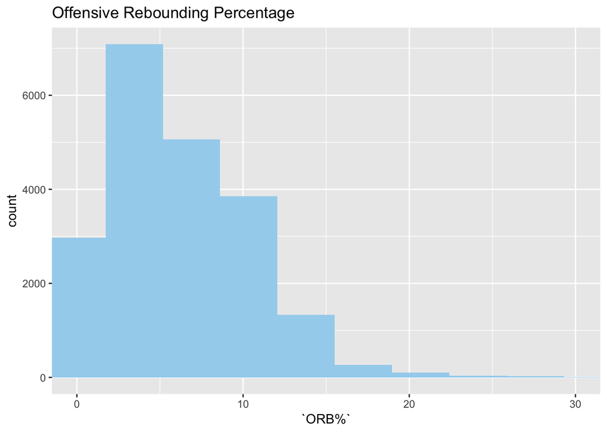

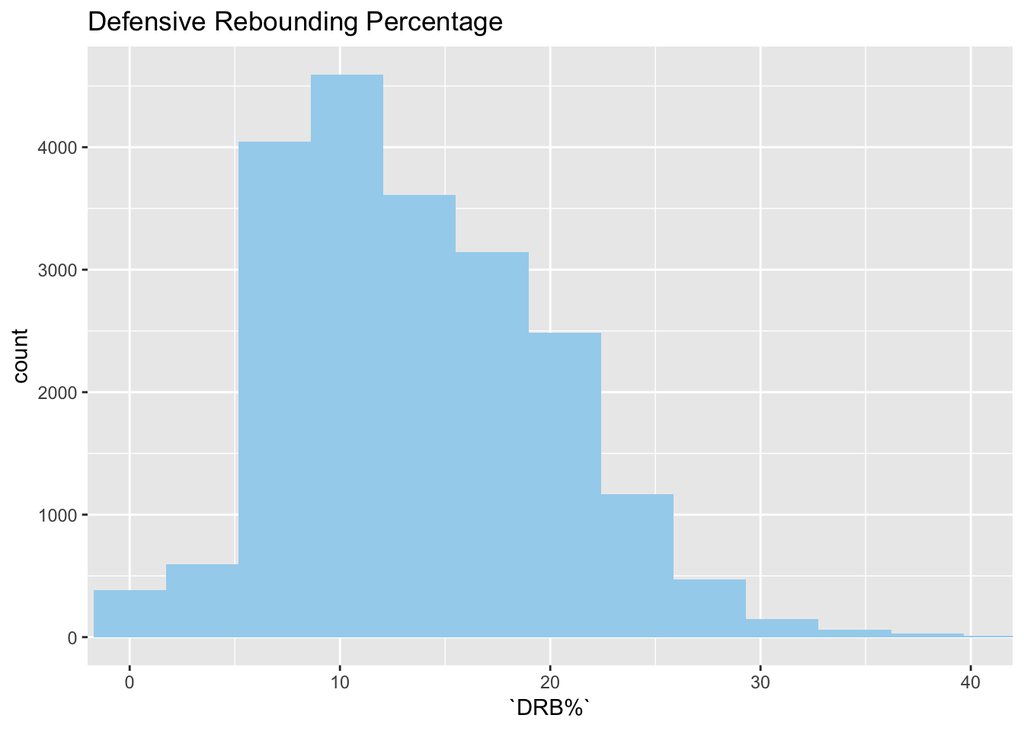

# RESULTS

#### QUESTION 1

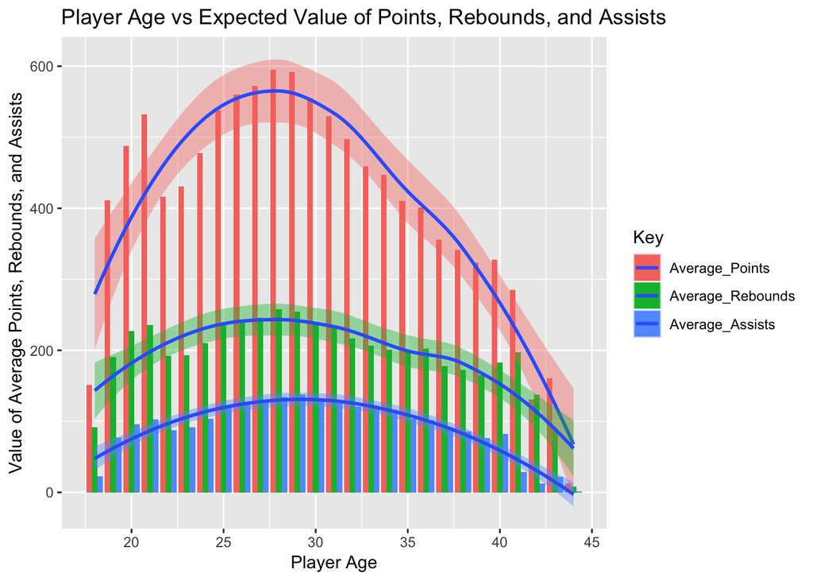

To further investigate, we decided to look into more advanced metrics like PER, WS, BPM, and VORP. These 4 advanced NBA metrics are potentially more indicative of true player performance and impact on their teams. To analyze these advanced metrics, we did close to the same sort of work in R as when we looked in point, rebound, and assist totals, grouping by age and looking at averages across metrics. The results are as follows: BPM and VORP peak at age 28, WS peaks at age 29, and PER peaks at age 43. One of these results quite obviously stands out among the rest, that being Player Efficiency Rating (PER). It is interesting that the metric which factors in players’ decision making abilities increases as a player gets older. Despite these results, and the fact that an overwhelming number of metrics are optimal at ages 27-29, we still have not yet found a way to predict when an NBA player will reach their prime. In the graphic below, BPM was scaled by a factor of 2 and VORP was scaled by a factor of 10 for readability.

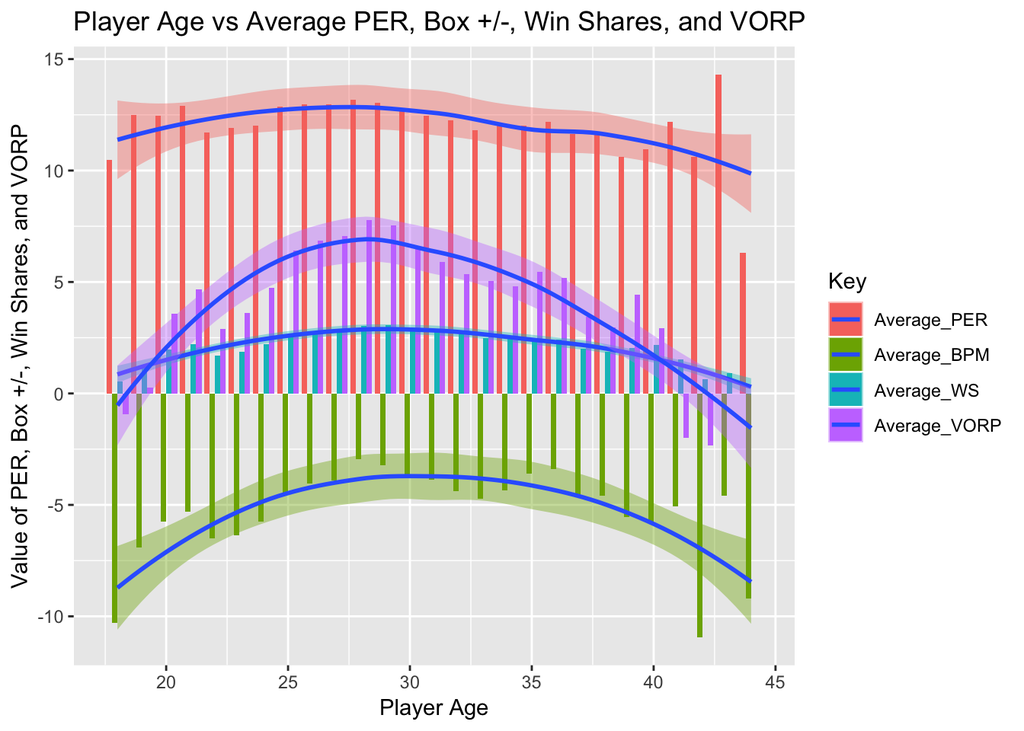

In order to model NBA player primes, we first needed a baseline for what a player’s prime was. To achieve this, we created a formula which could be used to make one all-encompassing index out of PER, BPM, VORP, WS, Points, Rebounds, and Assists, the 7 metrics we had explored previously. Of course, all of these metrics are weighted differently: LeBron James, over the course of his career, has a PER of 27.6 and a BPM of 9.1, for example. Because of this, we needed to normalize the metrics and make them proportionally valuable, so we multiplied each by a scalar which would bring the average of the metric times the scalar equal to 5 (Metric AVG * scalar = 5). We then added up all 7 of the scaled metrics and took the average, meaning the average NBA player had an index of 5 (which, after all calculations were done, they did). We then decided that the advanced metrics should be weighted twice, so we doubled their scalars to double count their weights. After creating this index, we applied it to each NBA player and each season they played. Then, we grouped by player and identified the season where that player had the best index. The age that the player was that particular season was the prime of their NBA career.

After creating this weightedIndex and identifying each player’s prime, we needed to create and clean more variables to predict off of. First, we decided to remove every entry where a player never actually played in an NBA game. Second, we removed every entry that had NA values in PER, WS, VORP, or BPM since they could have potentially created some unreliable weightedIndexes and player primes. Then, we mutated our data frame to include variables for the age at which a player entered the NBA as well as their rookie year point, rebound, and assist totals. We then altered our player positions variable for simplicity, changing all “C”, “C-F”, “C-PF”, “C-SF” to “Center”, all “F”, “F-C”, “F-G”, “PF”, “PF-C”, “PF-SF”, “SF”, “SF-PF”, “SF-PG”, and “SF-SG” to “Forward”, and all others to “Guard”. Finally, we put all of the necessary variables into one clean data frame (pictured above), including player name, prime age, weightedIndex rating, age entered NBA, college attended, birth state, height, weight, position, Year-1 points, Year-1 assists, and Year-1 rebounds.

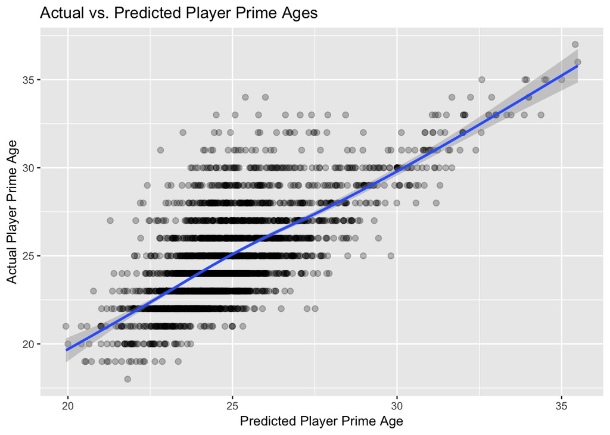

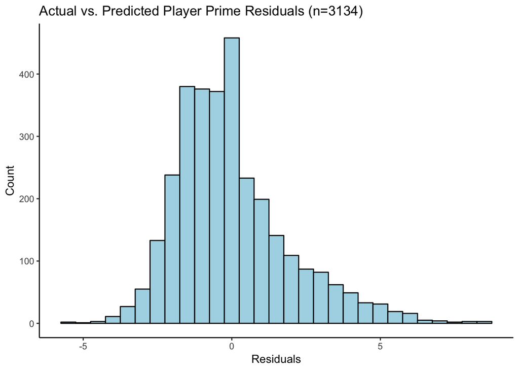

While these are not indicative of an extremely powerful model, the reasons for its inaccuracy actually provided very interesting insights. The average predicted age of an NBA player’s prime from the model was 24.92 years old. This is significantly different from the age our metrics of $PER$, $BPM$, $VORP$, $WS$, points, rebounds, and assists would suggest, around 27-29. The reason for this is that we calculated the prime of the average NBA player in the model, whereas we calculated the average by age in our graphs. The disparity arises because there are many NBA players who do not play for more than a few seasons due to injury or simply not being good enough, making their individual prime, what we calculated with the weightedIndex, occur at a very young age. NBA players who are more talented and who stay healthy, or, in other words, those who don’t exit the NBA early on, are more likely to have their primes occur around age 27-29. Also, our Residual Standard Error of 2.1 provides an interesting insight. NBA players do not necessarily have a prime in one singular year, often spanning across a few consecutive seasons. An error of around 2 suggests that the model accurately predicted an age for a player which was in a 3 year span of their individual prime.

#### QUESTION 2

In building a model for $ORB%$ and $DRB%$, we want to create a generalized linear model via penalized maximum likelihood. This is made possible by using R’s glmnet function. glmnet will successively optimize our objective function over each parameter while keeping our other parameters constant. We remove $ORB%$ from our $DRB%$ model and vice versa in order to remove all rebounding parameters from our model, as a high $ORB%$ is often indicative of a high $DRB%$. We then create models using glmnet() with $ORB%$ and $DRB.$ as our independent variables, and the rest of our variables as dependent.

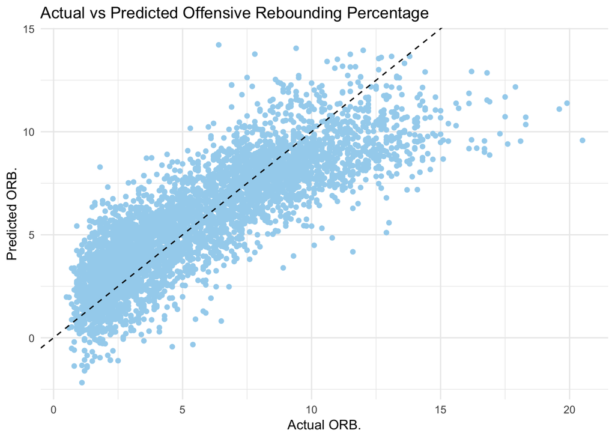

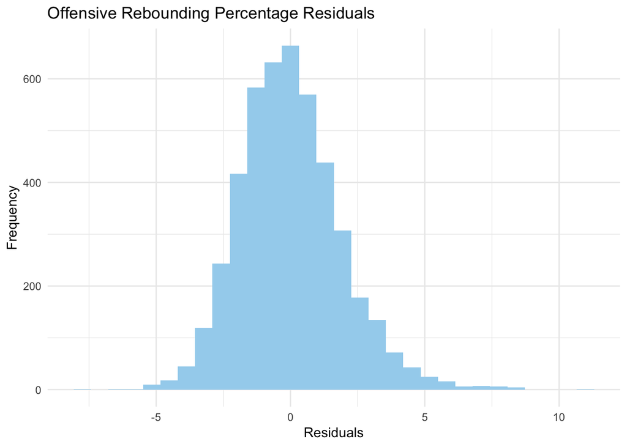

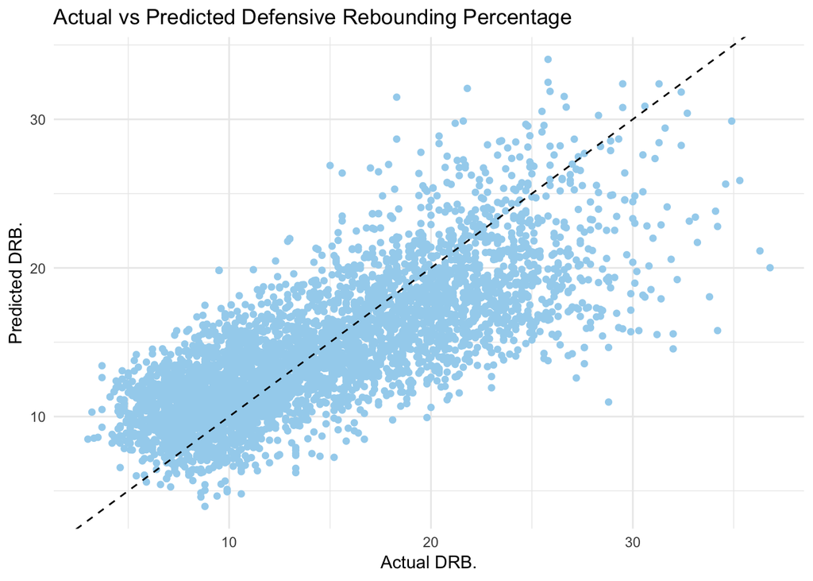

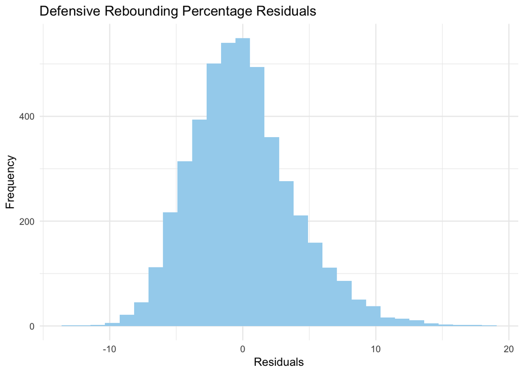

Offensive Rebounding Percentage

|  | s0 |
| --- | --- |
| (Intercept) | 10.23 |
| Age | -0.01 |
| TS. | -11.58 |
| X3PAr | -7.13 |
| FTr | 1.94 |
| AST. | -0.19 |
| STL. | -0.13 |
| BLK. | 0.39 |
| TOV. | 0.25 |
| OWS | 0.36 |
| DWS | 0.30 |

Defensive Rebounding Percentage

|  | s0 |
| --- | --- |
| (Intercept) | 10.75 |
| Age | 0.00 |
| TS. | 0.00 |
| X3PAr | -2.51 |
| FTr | 4.45 |
| AST. | -0.14 |
| STL. | -1.72 |
| BLK. | 1.06 |
| TOV. | 0.13 |
| OWS | 0.00 |
| DWS | 1.71 |

Now, we want to select the best model for each of ORB. and DRB.. To do this, we again using glmnet() and set lambda and alpha to their optimal (minimum) values that we discovered in our cross validation process. From here we make prediction variables $\hat{ORB.}$ and $\hat{DRB.}$ to predict these rebounding percentages from our model. Above are plots of actual vs. predicted for both $ORB%$ and $DRB%$ as well as histograms of the residuals for each variable. Both actual vs. predicted plots are concentrated around the $y=x$ line which would indicate a strong model. Our residuals are also normally distributed around 0, which would indicate a linear relationship. The next tables illustrate the coefficients of our models. From these tables, we can examine these coefficients and note the differences between which variables affect $ORB%$ differently than $DRB%$. We can see that while $Age$ has a negative sign for $ORB%$, it is not included in our model for $DRB%$. $TS%$ has a drastically different coefficient for each rebounding percentage. $TS%$ drastically decreases $ORB%$. Intuitively, this suggests that players that are prolific and efficient scorers are often more responsible for scoring, and thus less focused on grabbing offensive rebounds. Increased $TS%$ has no negative effect $DRB%$. $X3PAr$ also negatively affects both $ORB%$ and $DRB%$. We would expect players that attempt a larger percentage of their shots from 3-point territory to most often be near the 3-point line and less likely to be near the basket to get offensive rebounds. The opposite sentiment can be applied to $FTr$. Fouls occur most often near the basket, so players that shoot a lot of free throws in relation to their total field goal attempts would be near the basket at a higher rate, and thus more likely to grab offensive rebounds. Similarly, most players that assist on a large percentage of their teams possessions will not also be in a position to grab offensive rebounds. Players that play close to the basket often have worse ball handling skills, which would indicate why higher turnover percentage suggests higher rebounding percentages. Because the factors we have discussed so far are related to the offensive end of the floor, we do not expect them to have as drastic of an effect on $DRB%$, but because $ORB%$ and $DRB%$ are correlated, we would expect the signs of the coefficients to remain the same for both. On the defensive end, we see that higher block percentage results in a higher predicted defensive rebounding percentage while a higher steal percentage results in a lower predicted defensive rebounding position. Steal percentage effects $DRB%$ in a similar manner as to how assist percentage effects $ORB%$. Because players often grab the ball after a block, which is recorded as a defensive rebound, it would follow intuitively that a one percent increase in block percentage corresponds to one percent increase in defensive rebounding percentage. Our data also suggests that defensive rebounding is more strongly associated with defensive win shares than offensive rebounding is with offensive win shares.

# CONCLUSION